# Jurkat project

Juba

2025-11-23

# Project description

We are studying the effect of an inhibitor of the cGAS-STING signaling pathway **H151** on T-ALL model cell line **Jurkat**.

The biological experiment revealed that H151 causes cell death, so the pathway is important for survival of T-ALL.

We want to explore the differential expressed genes between normal condition and by inhibiting the pathway. Thus we are going to perform a differential expression analysis (DEA) followed by a pathway enrichment analysis (PEA)

**Following a basic RNA-seq pipeline analysis**

# Importing data

## Raw counts

|  | LXGP1 | LXGP2 | LXGP3 | LXGP4 | LXGP5 | LXGP6 |
| --- | --- | --- | --- | --- | --- | --- |
| ENSG00000044574 | 41987 | 45612 | 64980 | 147766 | 132552 | 133268 |
| ENSG00000101255 | 2049 | 2218 | 3190 | 15438 | 13106 | 13108 |
| ENSG00000104738 | 11232 | 11947 | 16580 | 5952 | 5221 | 5053 |
| ENSG00000105281 | 9384 | 9686 | 14322 | 36140 | 31096 | 30914 |
| ENSG00000135069 | 10235 | 10668 | 15150 | 37716 | 31542 | 33779 |
| ENSG00000140961 | 220 | 208 | 294 | 4004 | 3560 | 3366 |
| ENSG00000151012 | 744 | 840 | 1118 | 11671 | 9716 | 9983 |
| ENSG00000168003 | 10539 | 10321 | 15056 | 55194 | 49164 | 46442 |
| ENSG00000198431 | 16181 | 15788 | 23172 | 52837 | 45069 | 45461 |
| ENSG00000112118 | 12638 | 13028 | 18568 | 8233 | 7058 | 7050 |

[output cut: 9990 more lines]

## Metadata

|  | Chromosome_name | Start_gene_position | End_gene_position | Gene_name | Gene_biotype | Gene_Length |
| --- | --- | --- | --- | --- | --- | --- |
| ENSG00000044574 | chr9 | 125234853 | 125241382 | HSPA5 | protein_coding | 6529 |
| ENSG00000101255 | chr20 | 362835 | 397559 | TRIB3 | protein_coding | 34724 |
| ENSG00000104738 | chr8 | 47960185 | 47978160 | MCM4 | protein_coding | 17975 |
| ENSG00000105281 | chr19 | 46774883 | 46788594 | SLC1A5 | protein_coding | 13711 |
| ENSG00000135069 | chr9 | 78297125 | 78330093 | PSAT1 | protein_coding | 32968 |
| ENSG00000140961 | chr16 | 83931311 | 83966332 | OSGIN1 | protein_coding | 35021 |
| ENSG00000151012 | chr4 | 138164097 | 138242349 | SLC7A11 | protein_coding | 78252 |
| ENSG00000168003 | chr11 | 62856004 | 62888880 | SLC3A2 | protein_coding | 32876 |
| ENSG00000198431 | chr12 | 104215779 | 104350307 | TXNRD1 | protein_coding | 134528 |
| ENSG00000112118 | chr6 | 52264014 | 52284881 | MCM3 | protein_coding | 20867 |

[output cut: 9990 more lines]

## Experimental data

|  | Name | Concentration | Volume | Condition | Replicat |
| --- | --- | --- | --- | --- | --- |
| LXGP1 | JK1 | 74.63 | 4.02 | Jurkat_ct | 1 |
| LXGP2 | JK2 | 79.86 | 3.76 | Jurkat_ct | 2 |
| LXGP3 | JK3 | 79.12 | 3.79 | Jurkat_ct | 3 |
| LXGP4 | JK4 | 72.11 | 4.16 | Jurkat_H151 | 1 |
| LXGP5 | JK5 | 78.79 | 3.81 | Jurkat_H151 | 2 |
| LXGP6 | JK6 | 75.29 | 3.98 | Jurkat_H151 | 3 |

# Data exploration

First let’s view the distribution of the different bio types we have in our data :

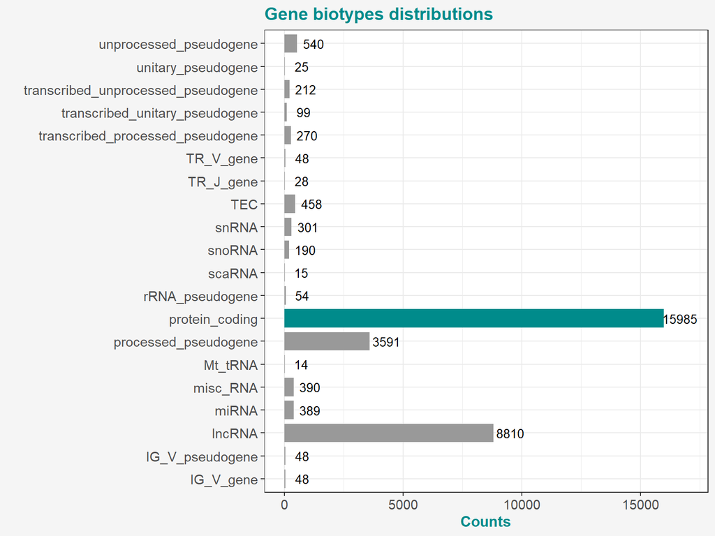

In the downstream analysis (DEA), we’ll be focusing on the top 2 biotypes (`protein_coding` and `lncRNA`). Additional filtering will be applied :

- `MaxCount_threshold` = **20** (At least 1 sample must have a read count over that value)
- `CpmCount_threshold` = **0.5** (Count per million reads threshold)
- `MinSample` = **3** (Samples that should pass the cpm threshold)

Now to understand the global gene expression landscape and to assess the quality control of our data, we need to perform a dimentionality reduction analysis : Principal component analysis (PCA)

The PCA :

- Assumes homoscedasticity (equal variance) between the samples
- Assumes roughly normal distribution

So we need to perform some data transformation first on `raw counts`.

We’ll be using a Variance Stabilizing Transformation (VST) from the `DESeq2` package. And This will :

- Normalize for library size (`DESeq2` computes size factors using a `median-of-ratios` method)
- Use a **negative binomial** model to estimate dispersion
- Apply a variance-stabilizing mathematical transformation

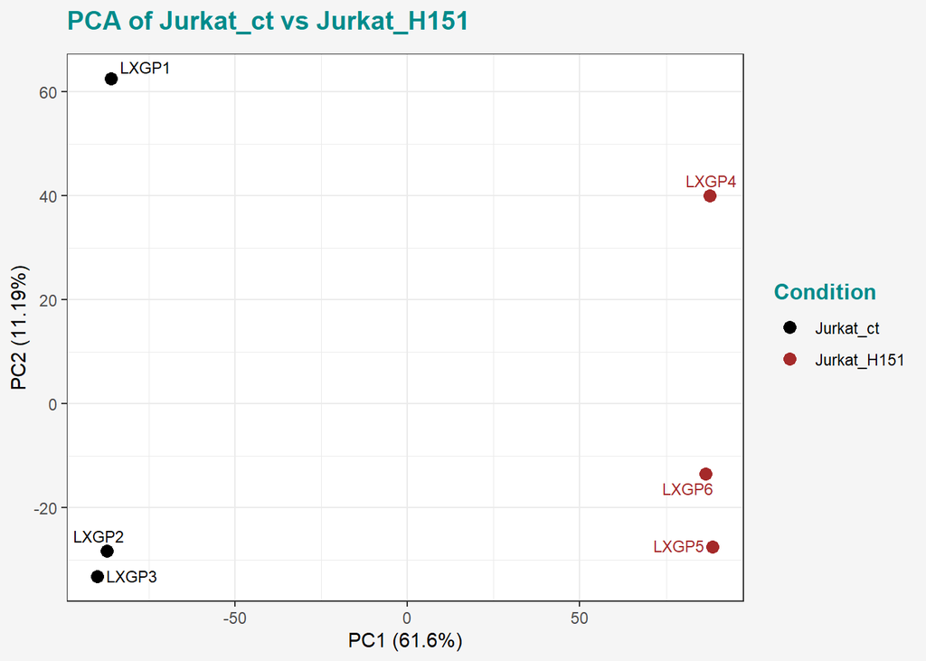